# Risk Factor Analysis

## Outcome Variable

**Outcome Variable:** ever_swasted

## Predictor Variables

**Intervention Variable:** vagbrth

**Adjustment Set:**

- arm
- sex
- W_mage
- meducyrs
- feducyrs
- hhwealth_quart
- W_mhtcm
- W_mwtkg
- W_mbmi
- single
- W_nrooms
- brthmon
- W_parity
- delta_W_mage
- delta_meducyrs
- delta_feducyrs
- delta_hhwealth_quart
- delta_W_mhtcm
- delta_W_mwtkg
- delta_W_mbmi
- delta_single
- delta_W_nrooms
- delta_brthmon
- delta_W_parity

## Stratifying Variables

The analysis was stratified on these variable(s):

- agecat
- studyid
- country

## Data Summary

| agecat | studyid | country | vagbrth | ever_swasted | n_cell | n |
| --- | --- | --- | --- | --- | --- | --- |
| 0-24 months (no birth wast) | CMC-V-BCS-2002 | INDIA | 0 | 0 | 20 | 368 |
| 0-24 months (no birth wast) | CMC-V-BCS-2002 | INDIA | 0 | 1 | 5 | 368 |
| 0-24 months (no birth wast) | CMC-V-BCS-2002 | INDIA | 1 | 0 | 293 | 368 |
| 0-24 months (no birth wast) | CMC-V-BCS-2002 | INDIA | 1 | 1 | 50 | 368 |
| 0-24 months (no birth wast) | IRC | INDIA | 0 | 0 | 55 | 409 |
| 0-24 months (no birth wast) | IRC | INDIA | 0 | 1 | 15 | 409 |
| 0-24 months (no birth wast) | IRC | INDIA | 1 | 0 | 277 | 409 |
| 0-24 months (no birth wast) | IRC | INDIA | 1 | 1 | 62 | 409 |
| 0-24 months (no birth wast) | JiVitA-3 | BANGLADESH | 0 | 0 | 1454 | 26404 |
| 0-24 months (no birth wast) | JiVitA-3 | BANGLADESH | 0 | 1 | 36 | 26404 |
| 0-24 months (no birth wast) | JiVitA-3 | BANGLADESH | 1 | 0 | 24005 | 26404 |
| 0-24 months (no birth wast) | JiVitA-3 | BANGLADESH | 1 | 1 | 909 | 26404 |
| 0-24 months (no birth wast) | JiVitA-4 | BANGLADESH | 0 | 0 | 358 | 4499 |
| 0-24 months (no birth wast) | JiVitA-4 | BANGLADESH | 0 | 1 | 12 | 4499 |
| 0-24 months (no birth wast) | JiVitA-4 | BANGLADESH | 1 | 0 | 3933 | 4499 |
| 0-24 months (no birth wast) | JiVitA-4 | BANGLADESH | 1 | 1 | 196 | 4499 |
| 0-24 months (no birth wast) | NIH-Crypto | BANGLADESH | 0 | 0 | 198 | 496 |
| 0-24 months (no birth wast) | NIH-Crypto | BANGLADESH | 0 | 1 | 4 | 496 |
| 0-24 months (no birth wast) | NIH-Crypto | BANGLADESH | 1 | 0 | 284 | 496 |
| 0-24 months (no birth wast) | NIH-Crypto | BANGLADESH | 1 | 1 | 10 | 496 |
| 0-24 months (no birth wast) | PROBIT | BELARUS | 0 | 0 | 1926 | 16879 |
| 0-24 months (no birth wast) | PROBIT | BELARUS | 0 | 1 | 26 | 16879 |
| 0-24 months (no birth wast) | PROBIT | BELARUS | 1 | 0 | 14749 | 16879 |
| 0-24 months (no birth wast) | PROBIT | BELARUS | 1 | 1 | 178 | 16879 |
| 0-24 months (no birth wast) | PROVIDE | BANGLADESH | 0 | 0 | 158 | 687 |
| 0-24 months (no birth wast) | PROVIDE | BANGLADESH | 0 | 1 | 1 | 687 |
| 0-24 months (no birth wast) | PROVIDE | BANGLADESH | 1 | 0 | 510 | 687 |
| 0-24 months (no birth wast) | PROVIDE | BANGLADESH | 1 | 1 | 18 | 687 |
| 0-24 months (no birth wast) | TanzaniaChild2 | TANZANIA, UNITED REPUBLIC OF | 0 | 0 | 195 | 2355 |
| 0-24 months (no birth wast) | TanzaniaChild2 | TANZANIA, UNITED REPUBLIC OF | 0 | 1 | 17 | 2355 |
| 0-24 months (no birth wast) | TanzaniaChild2 | TANZANIA, UNITED REPUBLIC OF | 1 | 0 | 2039 | 2355 |
| 0-24 months (no birth wast) | TanzaniaChild2 | TANZANIA, UNITED REPUBLIC OF | 1 | 1 | 104 | 2355 |
| 0-24 months (no birth wast) | ZVITAMBO | ZIMBABWE | 0 | 0 | 1110 | 13522 |
| 0-24 months (no birth wast) | ZVITAMBO | ZIMBABWE | 0 | 1 | 32 | 13522 |
| 0-24 months (no birth wast) | ZVITAMBO | ZIMBABWE | 1 | 0 | 11940 | 13522 |
| 0-24 months (no birth wast) | ZVITAMBO | ZIMBABWE | 1 | 1 | 440 | 13522 |

The following strata were considered:

- agecat: 0-24 months (no birth wast), studyid: CMC-V-BCS-2002, country: INDIA
- agecat: 0-24 months (no birth wast), studyid: IRC, country: INDIA
- agecat: 0-24 months (no birth wast), studyid: JiVitA-3, country: BANGLADESH
- agecat: 0-24 months (no birth wast), studyid: JiVitA-4, country: BANGLADESH
- agecat: 0-24 months (no birth wast), studyid: NIH-Crypto, country: BANGLADESH
- agecat: 0-24 months (no birth wast), studyid: PROBIT, country: BELARUS
- agecat: 0-24 months (no birth wast), studyid: PROVIDE, country: BANGLADESH
- agecat: 0-24 months (no birth wast), studyid: TanzaniaChild2, country: TANZANIA, UNITED REPUBLIC OF
- agecat: 0-24 months (no birth wast), studyid: ZVITAMBO, country: ZIMBABWE

### Dropped Strata

Some strata were dropped due to rare outcomes:

- agecat: 0-24 months (no birth wast), studyid: NIH-Crypto, country: BANGLADESH
- agecat: 0-24 months (no birth wast), studyid: PROVIDE, country: BANGLADESH

## Methods Detail

We're interested in the causal parameters $E[Y_a]$ for all values of $a \in \mathcal{A}$. These parameters represent the mean outcome if, possibly contrary to fact, we intervened to set all units to have $A=a$. Under the randomization and positivity assumptions, these are identified by the statistical parameters $\psi_a=E_W[E_{Y|A,W}(Y|A=a,W)]$. In addition, we're interested in the mean of $Y$, $E[Y]$ under no intervention (the observed mean). We will estimate these parameters by using SuperLearner to fit the relevant likelihood factors -- $E_{Y|A,W}(Y|A=a,W)$ and $p(A=a|W)$, and then updating our likelihood fit using a joint TMLE.

For unadjusted analyses ($W=\{\}$), initial likelihoods were estimated using Lrnr_glm to estimate the simple $E(Y|A)$ and Lrnr_mean to estimate $p(A)$. For adjusted analyses, a small library containing Lrnr_glmnet, Lrnr_xgboost, and Lrnr_mean was used.

Having estimated these parameters, we will then use the delta method to estimate relative risks and attributable risks relative to a prespecified baseline level of $A$.

# Results Detail

## Results Plots

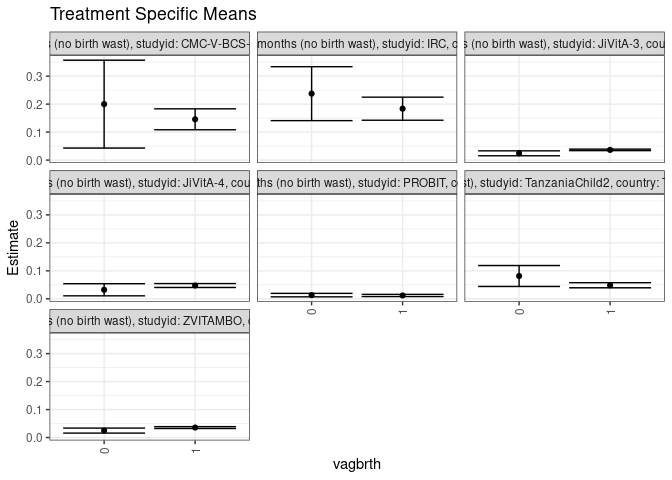

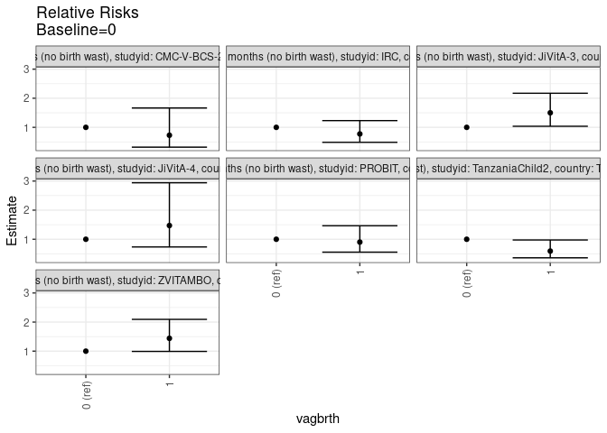

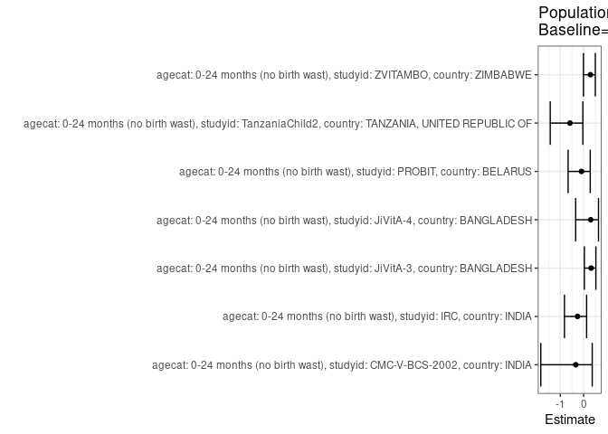

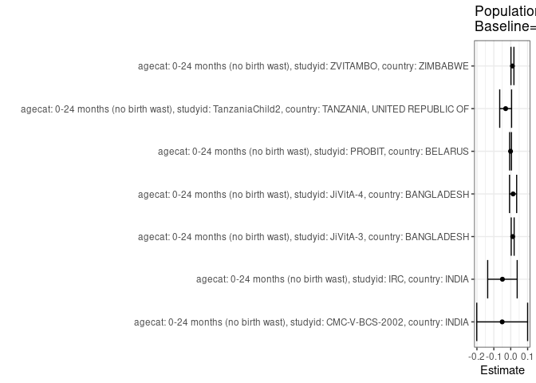

## Results Table

### Parameter: TSM

| agecat | studyid | country | intervention_level | baseline_level | estimate | ci_lower | ci_upper |
| --- | --- | --- | --- | --- | --- | --- | --- |
| 0-24 months (no birth wast) | CMC-V-BCS-2002 | INDIA | 0 | NA | 0.2000000 | 0.0429894 | 0.3570106 |
| 0-24 months (no birth wast) | CMC-V-BCS-2002 | INDIA | 1 | NA | 0.1457726 | 0.1083773 | 0.1831679 |
| 0-24 months (no birth wast) | IRC | INDIA | 0 | NA | 0.2374133 | 0.1410337 | 0.3337929 |
| 0-24 months (no birth wast) | IRC | INDIA | 1 | NA | 0.1836835 | 0.1424754 | 0.2248915 |
| 0-24 months (no birth wast) | JiVitA-3 | BANGLADESH | 0 | NA | 0.0243059 | 0.0154874 | 0.0331244 |
| 0-24 months (no birth wast) | JiVitA-3 | BANGLADESH | 1 | NA | 0.0364773 | 0.0337950 | 0.0391597 |
| 0-24 months (no birth wast) | JiVitA-4 | BANGLADESH | 0 | NA | 0.0322743 | 0.0105535 | 0.0539950 |
| 0-24 months (no birth wast) | JiVitA-4 | BANGLADESH | 1 | NA | 0.0474827 | 0.0405010 | 0.0544644 |
| 0-24 months (no birth wast) | PROBIT | BELARUS | 0 | NA | 0.0132112 | 0.0069930 | 0.0194294 |
| 0-24 months (no birth wast) | PROBIT | BELARUS | 1 | NA | 0.0119270 | 0.0079908 | 0.0158632 |
| 0-24 months (no birth wast) | TanzaniaChild2 | TANZANIA, UNITED REPUBLIC OF | 0 | NA | 0.0815092 | 0.0441071 | 0.1189112 |
| 0-24 months (no birth wast) | TanzaniaChild2 | TANZANIA, UNITED REPUBLIC OF | 1 | NA | 0.0484202 | 0.0393269 | 0.0575135 |
| 0-24 months (no birth wast) | ZVITAMBO | ZIMBABWE | 0 | NA | 0.0247732 | 0.0158043 | 0.0337421 |
| 0-24 months (no birth wast) | ZVITAMBO | ZIMBABWE | 1 | NA | 0.0356820 | 0.0324079 | 0.0389561 |

### Parameter: E(Y)

| agecat | studyid | country | intervention_level | baseline_level | estimate | ci_lower | ci_upper |
| --- | --- | --- | --- | --- | --- | --- | --- |
| 0-24 months (no birth wast) | CMC-V-BCS-2002 | INDIA | NA | NA | 0.1494565 | 0.1129794 | 0.1859337 |
| 0-24 months (no birth wast) | IRC | INDIA | NA | NA | 0.1882641 | 0.1503318 | 0.2261964 |
| 0-24 months (no birth wast) | JiVitA-3 | BANGLADESH | NA | NA | 0.0357900 | 0.0332085 | 0.0383715 |
| 0-24 months (no birth wast) | JiVitA-4 | BANGLADESH | NA | NA | 0.0462325 | 0.0396215 | 0.0528435 |
| 0-24 months (no birth wast) | PROBIT | BELARUS | NA | NA | 0.0120860 | 0.0083142 | 0.0158578 |
| 0-24 months (no birth wast) | TanzaniaChild2 | TANZANIA, UNITED REPUBLIC OF | NA | NA | 0.0513800 | 0.0424616 | 0.0602985 |
| 0-24 months (no birth wast) | ZVITAMBO | ZIMBABWE | NA | NA | 0.0349061 | 0.0318124 | 0.0379998 |

### Parameter: RR

| agecat | studyid | country | intervention_level | baseline_level | estimate | ci_lower | ci_upper |
| --- | --- | --- | --- | --- | --- | --- | --- |
| 0-24 months (no birth wast) | CMC-V-BCS-2002 | INDIA | 0 | 0 | 1.0000000 | 1.0000000 | 1.0000000 |
| 0-24 months (no birth wast) | CMC-V-BCS-2002 | INDIA | 1 | 0 | 0.7288630 | 0.3191248 | 1.6646817 |
| 0-24 months (no birth wast) | IRC | INDIA | 0 | 0 | 1.0000000 | 1.0000000 | 1.0000000 |
| 0-24 months (no birth wast) | IRC | INDIA | 1 | 0 | 0.7736864 | 0.4861956 | 1.2311724 |
| 0-24 months (no birth wast) | JiVitA-3 | BANGLADESH | 0 | 0 | 1.0000000 | 1.0000000 | 1.0000000 |
| 0-24 months (no birth wast) | JiVitA-3 | BANGLADESH | 1 | 0 | 1.5007586 | 1.0371630 | 2.1715742 |
| 0-24 months (no birth wast) | JiVitA-4 | BANGLADESH | 0 | 0 | 1.0000000 | 1.0000000 | 1.0000000 |
| 0-24 months (no birth wast) | JiVitA-4 | BANGLADESH | 1 | 0 | 1.4712259 | 0.7357700 | 2.9418236 |
| 0-24 months (no birth wast) | PROBIT | BELARUS | 0 | 0 | 1.0000000 | 1.0000000 | 1.0000000 |
| 0-24 months (no birth wast) | PROBIT | BELARUS | 1 | 0 | 0.9027900 | 0.5564445 | 1.4647098 |
| 0-24 months (no birth wast) | TanzaniaChild2 | TANZANIA, UNITED REPUBLIC OF | 0 | 0 | 1.0000000 | 1.0000000 | 1.0000000 |
| 0-24 months (no birth wast) | TanzaniaChild2 | TANZANIA, UNITED REPUBLIC OF | 1 | 0 | 0.5940461 | 0.3618988 | 0.9751089 |
| 0-24 months (no birth wast) | ZVITAMBO | ZIMBABWE | 0 | 0 | 1.0000000 | 1.0000000 | 1.0000000 |
| 0-24 months (no birth wast) | ZVITAMBO | ZIMBABWE | 1 | 0 | 1.4403463 | 0.9914966 | 2.0923899 |

### Parameter: PAR

| agecat | studyid | country | intervention_level | baseline_level | estimate | ci_lower | ci_upper |
| --- | --- | --- | --- | --- | --- | --- | --- |
| 0-24 months (no birth wast) | CMC-V-BCS-2002 | INDIA | 0 | NA | -0.0505435 | -0.2009875 | 0.0999006 |
| 0-24 months (no birth wast) | IRC | INDIA | 0 | NA | -0.0491493 | -0.1363925 | 0.0380939 |
| 0-24 months (no birth wast) | JiVitA-3 | BANGLADESH | 0 | NA | 0.0114841 | 0.0028032 | 0.0201649 |
| 0-24 months (no birth wast) | JiVitA-4 | BANGLADESH | 0 | NA | 0.0139582 | -0.0071521 | 0.0350686 |
| 0-24 months (no birth wast) | PROBIT | BELARUS | 0 | NA | -0.0011252 | -0.0066310 | 0.0043806 |
| 0-24 months (no birth wast) | TanzaniaChild2 | TANZANIA, UNITED REPUBLIC OF | 0 | NA | -0.0301291 | -0.0652434 | 0.0049851 |
| 0-24 months (no birth wast) | ZVITAMBO | ZIMBABWE | 0 | NA | 0.0101329 | 0.0014123 | 0.0188535 |

### Parameter: PAF

| agecat | studyid | country | intervention_level | baseline_level | estimate | ci_lower | ci_upper |
| --- | --- | --- | --- | --- | --- | --- | --- |
| 0-24 months (no birth wast) | CMC-V-BCS-2002 | INDIA | 0 | NA | -0.3381818 | -1.8354235 | 0.3684433 |
| 0-24 months (no birth wast) | IRC | INDIA | 0 | NA | -0.2610656 | -0.8226514 | 0.1274873 |
| 0-24 months (no birth wast) | JiVitA-3 | BANGLADESH | 0 | NA | 0.3208742 | 0.0309246 | 0.5240702 |
| 0-24 months (no birth wast) | JiVitA-4 | BANGLADESH | 0 | NA | 0.3019140 | -0.3413960 | 0.6367038 |
| 0-24 months (no birth wast) | PROBIT | BELARUS | 0 | NA | -0.0931002 | -0.6658804 | 0.2827408 |
| 0-24 months (no birth wast) | TanzaniaChild2 | TANZANIA, UNITED REPUBLIC OF | 0 | NA | -0.5863977 | -1.4306992 | -0.0353637 |
| 0-24 months (no birth wast) | ZVITAMBO | ZIMBABWE | 0 | NA | 0.2902896 | -0.0075310 | 0.5000760 |